# Clustering GAINCapital clients with K_Means

Taras Poltorak

02/05/2020

## Introduction

The point of this exercise is to apply a K-Means clustering algorithm to a dataset of customers based on their age, trading experience, income etc.

```r
library(readxl)
library(tidyverse)
library(factoextra)
library(skimr)
```

## Load and explore the data

```r
df <- read_excel("Clustering_CaseStudy_28042020.xlsx")

df <- df %>% select(-1)
df <- rowid_to_column(df, "ID")

skim(df)
```

Data summary

| Name | df |
| --- | --- |
| Number of rows | 244291 |
| Number of columns | 14 |
| _______________________ |  |
| Column type frequency: |  |
| character | 7 |
| numeric | 7 |
| ________________________ |  |
| Group variables | None |

**Variable type: character**

| skim_variable | n_missing | complete_rate | min | max | empty | n_unique | whitespace |
| --- | --- | --- | --- | --- | --- | --- | --- |
| Service Offering | 0 | 1 | 12 | 12 | 0 | 1 | 0 |
| Sales Channel | 0 | 1 | 6 | 6 | 0 | 1 | 0 |
| Sales Sub Channel | 0 | 1 | 6 | 18 | 0 | 2 | 0 |
| Age Group | 0 | 1 | 4 | 7 | 0 | 10 | 0 |
| Date of Birth | 0 | 1 | 19 | 19 | 0 | 18867 | 0 |
| Gender | 0 | 1 | 2 | 6 | 0 | 3 | 0 |
| Device | 0 | 1 | 2 | 7 | 0 | 5 | 0 |

**Variable type: numeric**

| skim_variable | n_missing | complete_rate | mean | sd | p0 | p25 | p50 | p75 | p100 | hist |
| --- | --- | --- | --- | --- | --- | --- | --- | --- | --- | --- |
| ID | 0 | 1 | 122146.00 | 70520.88 | 1 | 61073.5 | 122146.0 | 183218.5 | 244291 | ▇▇▇▇▇ |
| Age Score | 0 | 1 | 3.49 | 2.07 | 1 | 2.0 | 3.0 | 4.0 | 10 | ▇▅▂▁▁ |
| Trading Experience Score | 4 | 1 | 2.79 | 4.77 | 0 | 0.0 | 0.0 | 4.0 | 80 | ▇▁▁▁▁ |
| Net Worth Score | 18 | 1 | 2.54 | 1.24 | 1 | 1.5 | 2.5 | 3.5 | 7 | ▇▅▅▁▁ |
| Income Score | 10 | 1 | 2.54 | 1.38 | 1 | 1.0 | 2.0 | 3.0 | 8 | ▇▃▃▁▁ |
| Gender_Sort | 0 | 1 | 1.25 | 0.45 | 1 | 1.0 | 1.0 | 1.0 | 3 | ▇▁▂▁▁ |
| Device_Sort | 0 | 1 | 1.89 | 0.76 | 1 | 1.0 | 2.0 | 2.0 | 4 | ▆▇▁▃▁ |

## Addressing missing values

There is a very small number of NA’s (missing values) in the dataset. Because the data is categorical we cannot impute them and, therefore, they will be removed. Also, we are removing the columns, which are not required for our exercise.

```r
df <- df %>% select(-`Sales Channel`,
                    -`Sales Sub Channel`,
                    -`Date of Birth`,
                    -`Gender`,
                    -`Device`,
                    -`Service Offering`,
                    -`Age Group`)  %>%
             drop_na()
```

## Standardising Values (Z-score)

Because K-Means uses distance calculations between values, we must standardise our features so that they are all within the same range. This will avoid one feature dominating others.

```r
df_clean <- df[2:6]
z_df <- as.data.frame(lapply(df_clean, scale))
```

## Model Training

```r
RNGversion("3.5.2") # Specify version and set seed for reproducibility
set.seed(123)

df_clusters <- kmeans(z_df, 5)
```

## Model Evaluation

The first time K-Means is applied to a dataset the number of clusters is set randomly. Although, it has to be noted, very often Data Scientist will have some idea about the expected clusters. This comes from practical knowledge about the data. In this instance, however, I have no prior knowledge about the clients and the number 5 is chosen randomly.

To asses the optimal number of clusters we use the Elbow Method.

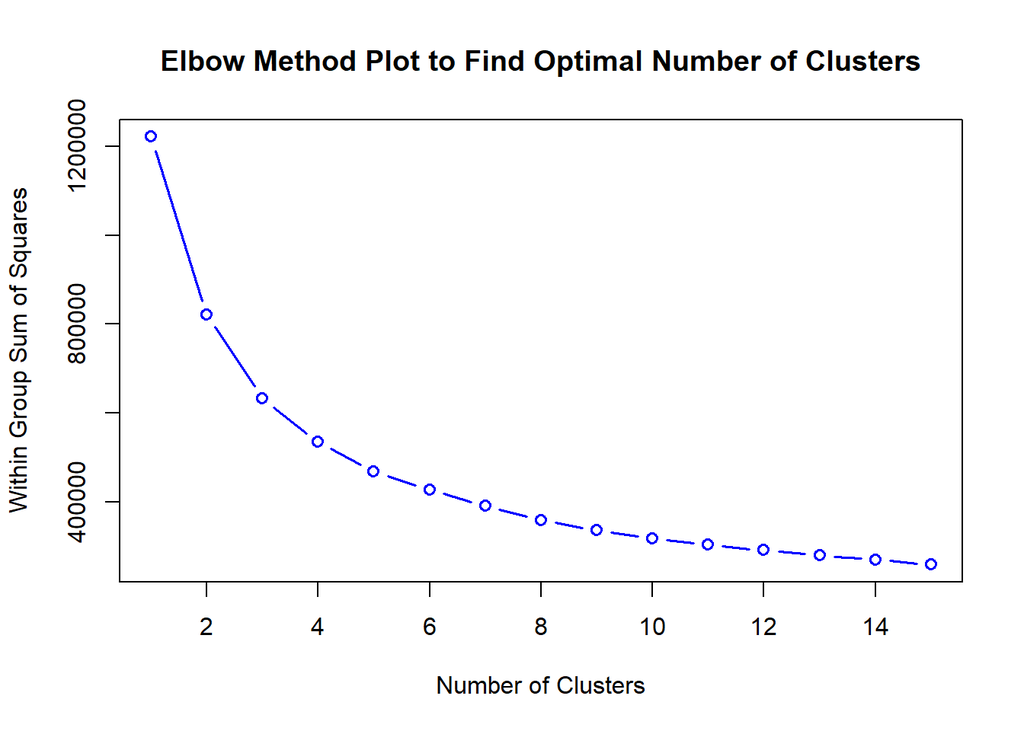

```r
#First we define a function and then apply it to our data

wssplot <- function(data, nc = 15, set.seed = 1234){
  wss <- (nrow(data) - 1)*sum(apply(data, 2, var))
  for(i in 2:nc) {
    set.seed(1234)
    wss[i] <- sum(kmeans(x = data, centers = i, nstart = 25)$withinss)
  }
  plot(1:nc, wss, type = 'b', xlab = 'Number of Clusters', ylab = 'Within Group Sum of Squares',
       main = 'Elbow Method Plot to Find Optimal Number of Clusters', frame.plot = T,
       col = 'blue', lwd = 1.5)
}

wssplot(z_df)
```

## Improving Model’s Performance

Let’s set the number of clusters to 3 (where the “elbow” is) and visualise the result.

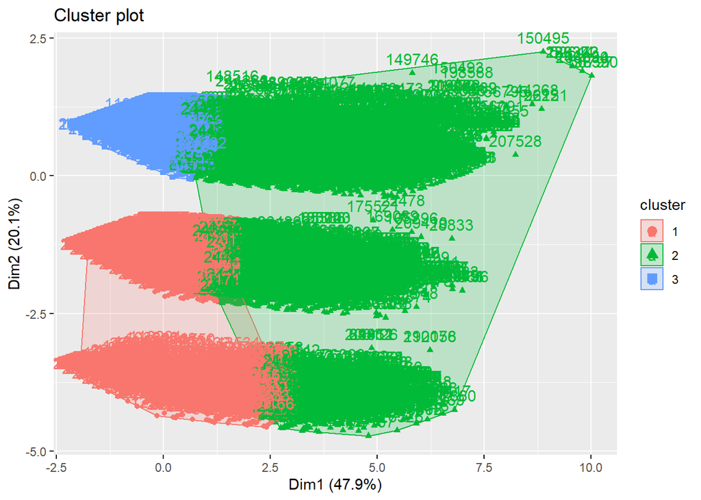

```r
df_clusters <- kmeans(z_df, 3)

fviz_cluster(df_clusters, data = z_df)
```

# Evaluating the Performance

Let’s look at the centres of clusters

```r
df_clusters$centers
```

```
##    Age.Score Trading.Experience.Score Net.Worth.Score Income.Score Gender_Sort
## 1 -0.2323664               -0.3708659      -0.3821355   -0.3603820   1.7298186
## 2  1.1705044                0.9802016       1.2990420    1.1638865  -0.2593359
## 3 -0.3878635               -0.2581343      -0.3834632   -0.3367572  -0.5488243
```

In the above table the 3 rows refer to our clusters. The numbers across each row indicate the cluster’s average value for the category listed at the top of the column. Because the values are standardised, positive values are above the overall mean and negative are bellow. The highest values are of most interest to their corresponding clusters.

## Assigning Clusters to the Original Data

Now we can assign clusters to the original dataset with client ID’s so we can tell, which cluster each client belongs to.

```r
df$cluster <- df_clusters$cluster



df
```

```
## # A tibble: 244,269 x 8
##       ID `Age Score` `Trading Experi~ `Net Worth Scor~ `Income Score`
##    <int>       <dbl>            <dbl>            <dbl>          <dbl>
##  1     1           2                2              1.5              2
##  2     2           3               15              5.5              2
##  3     3           2                5              2.5              2
##  4     4           2                8              3.5              3
##  5     5           2                1              3.5              3
##  6     6           6                1              2.5              3
##  7     7           4                0              7                1
##  8     8           5                0              2.5              3
##  9     9           2                0              1.5              1
## 10    10           2                0              1.5              2
## # ... with 244,259 more rows, and 3 more variables: Gender_Sort <dbl>,
## #   Device_Sort <dbl>, cluster <int>
```